# StatCompHomwork_21075

Yu Zheng_21075

2021-12-17

## All homework of StatComp (Fall term,2021) by Yu Zheng (ID: 21075)

This is an R Markdown document which includes all of the homework during the author studying the lesson, Statistical Computing (lecturer: Prof.Zhang, Fall,2021).

## 2021/9/16

## Question

Use knitr to produce at least 3 examples (texts, figures, tables)

## Answer

1、texts: 计算ρ(x,sqrt(1-x^2))

```r
corr=function(n)
{
u=runif(n)
results1=(mean(u*sqrt(1-u^2))-mean(u)*mean(sqrt(1-u^2)))/(sd(u)*sd(sqrt(1-u^2)))
results1
}
corr(1000000)
```

```
## [1] -0.9212981
```

2、figures： 画出向量X1、X2、X3两两之间的散点图，可以大概知道变量间的相关关系

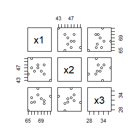

```r
rubber<-data.frame(x1=c(65,70,70,69,66,67,68,72,66,68),x2=c(45,45,48,46,50,46,47,43,47,48),x3=c(27.6,30.7,31.8,32.6,31.0,31.3,37.0,33.6,33.1,34.2))
plot(rubber)
```

3、tables: 制作一张表格,生成名为foo的csv文件

```r
##建立数据框
df<-data.frame(
   Name=c("张三","李四","王五","赵六","丁一"),
   Sex=c("女","男","女","男","女"),
   Age=c(14,15,16,14,15),
   Height=c(156,165,157,162,159),
   Weight=c(42.0,49.0,41.5,52.0,45.5)
);df
```

```
##   Name Sex Age Height Weight
## 1 张三  女  14    156   42.0
## 2 李四  男  15    165   49.0
## 3 王五  女  16    157   41.5
## 4 赵六  男  14    162   52.0
## 5 丁一  女  15    159   45.5
```

```r
write.csv(df,file="foo.csv")
##将数据框转为表格
```

## 2021/9/23

## Question

Exercises 3.4, 3.11, and 3.20 (pages 94-96, Statistical Computating with R)

## Answer

3.4:

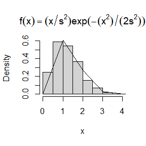

```r
rayleigh<-function(s)
{n <- 1000
u <- runif(n)
x <- sqrt(-2*s^2*log(1-u))
hist(x, prob = TRUE, main = expression(f(x)==(x/s^2)*exp(-(x^2)/(2*s^2))))
y <- seq(0, 100, 1)
lines(y, y/s^2*exp(-(y^2)/(2*s^2)))
}
####模拟σ=1,2,3的三种情况
rayleigh(1)
```

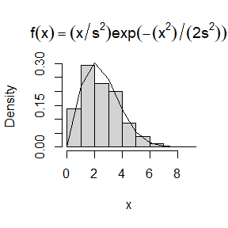

```r
rayleigh(2)
```

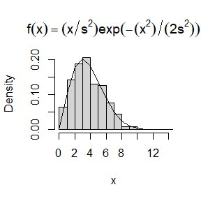

```r
rayleigh(3)
```

总结：由模拟结果知，逆变换法产生的rayleigh随机数的直方图与理论的密度函数拟合得很接近。

3.11：

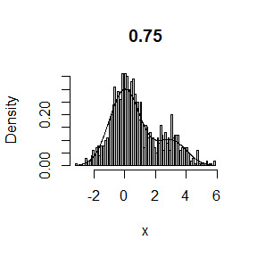

```r
mix<-function(n,p)
{
   u=rep(0, n)
   x=rep(0, n)
   for(i in 1:n)
   {
      u[i]=runif(1)
      if(u[i]<p){
         x[i]=rnorm(1)
         }
      else{
         x[i]=rnorm(1,3,1)
         }
   }
   hist(x,prob = TRUE,breaks=100,main = p)
   y=seq(min(x),max(x),0.01)
   lines(y,p/sqrt(2*pi)*exp(-y^2/2)+(1-p)/sqrt(2*pi)*exp(-(y-3)^2/2))
}
##模拟p1=0.75，0.4，0.5，,0.6的四种情况
mix(n = 1000,p=0.75)
```

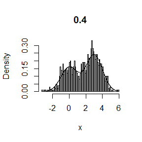

```r
mix(n = 1000,p=0.4)
```

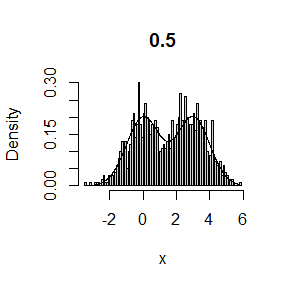

```r
mix(n = 1000,p=0.5)
```

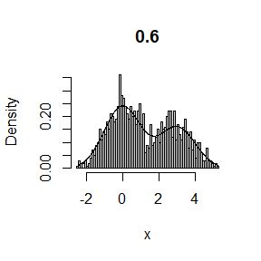

```r
mix(n = 1000,p=0.6)
```

总结：由图可得，当p1=0.5时，密度函数会出现双峰。

3.20:

```r
##生成泊松过程和伽马分布的复合随机变量，其中泊松过程参数为lambda，伽马分布的参数为r和beta
crp=function(n,lambda,r,beta)
{  x=0
   for(i in 1:n)
      {
      n=rpois(1,10*lambda)
      y=rgamma(n,r,beta)
      x[i]=sum(y)
   }
   estimate=c(mean(x),var(x))
   theore=c(10*lambda*r/beta,10*lambda*(r/(beta^2)+(r^2)/(beta^2)))
   list(estimate=estimate,theore=theore)
}
##选择不同的参数进行模拟
crp(10000,1,1,1)
```

```
## $estimate
## [1] 10.00453 20.34145
##
## $theore
## [1] 10 20
```

```r
crp(10000,3,2,4)
```

```
## $estimate
## [1] 15.00244 10.96982
##
## $theore
## [1] 15.00 11.25
```

```r
crp(10000,5,3,5)
```

```
## $estimate
## [1] 30.04144 23.48411
##
## $theore
## [1] 30 24
```

总结：由三次模拟的结果可知，当产生10000个模拟的随机数时，复合随机变量的均值和方差的模拟值和理论值非常接近，说明模拟效果比较好。

## 2021/9/30

## Question

Exercises 5.4, 5.9, 5.13, and 5.14 (pages 149-151, Statistical Computating with R).

## Answer

5.4:

```r
beta=function(q)
{
   n=length(q)
   theta.hat=c(0,n)
   for (i in 1:n) {
      g=function(u)q[i]*30*u^2*(1-u)^2
      y=runif(1e6,0,q[i])
      theta.hat[i]=mean(g(y))
  }
   theta.hat
}
q=seq(0.1,0.9,0.1)
list(MCe=round(beta(q),5),ture=pbeta(q,3,3))
```

```
## $MCe
## [1] 0.00856 0.05799 0.16323 0.31755 0.49985 0.68259 0.83659 0.94204 0.99130
##
## $ture
## [1] 0.00856 0.05792 0.16308 0.31744 0.50000 0.68256 0.83692 0.94208 0.99144
```

总结：由模拟结果知，用Monte Carlo方法估计的beta(3,3)的cdf与R中的pbeta函数计算出来的cdf是很接近的。

5.9：

```r
raylaigh=function(x,s=sigma)
{
m=50000
u=runif(m,0,x)
T1=(x*u/s^2*exp(-u^2/(2*s^2))+x*(x-u)/s^2*exp(-(x-u)^2/(2*s^2)))/2
u1=runif(m,0,x)
T2=(x*u/s^2*exp(-u^2/(2*s^2))+x*u1/s^2*exp(-u1^2/(2*s^2)))/2
list(meanT1=mean(T1),meanT2=mean(T2),varT1=var(T1)/m,varT2=var(T2)/m,percent_reduction=(var(T2)-var(T1))/var(T2))
}
##取x=1，sigma=2
raylaigh(1,2)
```

```
## $meanT1
## [1] 0.1174924
##
## $meanT2
## [1] 0.1175129
##
## $varT1
## [1] 2.118447e-10
##
## $varT2
## [1] 4.144339e-08
##
## $percent_reduction
## [1] 0.9948883
```

```r
##取x=2，sigma=2
raylaigh(2,2)
```

```
## $meanT1
## [1] 0.3933876
##
## $meanT2
## [1] 0.3944436
##
## $varT1
## [1] 3.473663e-08
##
## $varT2
## [1] 3.477287e-07
##
## $percent_reduction
## [1] 0.9001042
```

```r
##取x=3，sigma=2
raylaigh(3,2)
```

```
## $meanT1
## [1] 0.6753149
##
## $meanT2
## [1] 0.6768029
##
## $varT1
## [1] 4.393398e-07
##
## $varT2
## [1] 6.707792e-07
##
## $percent_reduction
## [1] 0.3450307
```

总结：由三次模拟结果知，当x与x’负相关时计算rayleigh（2）的cdf和当x1与x2独立时产生的rayleigh（2）的cdf是相近的，但是用对偶变量法产生的rayleigh（2）分布的估计的方差确实比独立变量产生的方差要小。说明对偶变量法能够有效缩减方差。

5.13:取f1为标准正态分布的密度函数，f2为参数为1的指数分布。且由后面的模拟结果知，选取f2为 importance function时，积分估计会有较小的方差。

5.14:

```r
##取f为标准正态分布的密度函数
m=1e6
x=rnorm(m)
g=x^2*(x>=1)
list(theta.hat=mean(g),vartheta.hat=var(g)/m)
```

```
## $theta.hat
## [1] 0.4007908
##
## $vartheta.hat
## [1] 1.290095e-06
```

```r
##取f为指数分布的密度函数
y=rexp(m)
g1=y^2/sqrt(2*pi)*exp(y-y^2/2)*(y>=1)
list(theta1.hat=mean(g1),vartheta1.hat=var(g1)/m)
```

```
## $theta1.hat
## [1] 0.4005636
##
## $vartheta1.hat
## [1] 3.434265e-07
```

```r
c(var(g)/var(g1))
```

```
## [1] 3.756539
```

总结： 1.由重要抽样法估计该积分为0.4左右； 2.由两者方差比值大于1知，取 importance function为指数分布（λ=1）的密度函数时，积分估计的方差较小，取importance function为标准正态分布的密度函数时，积分估计的方差较大。

## 2021-10-14

## Question

一、Exercises 6.5 and 6.A (page 180-181, Statistical Computating with R).\ 二、If we obtain the powers for two methods under a particular simulation setting with 10,000 experiments: say, 0.651 for one method and 0.676 for another method. We want to know if the powers are different at 0.05 level.\ 1.What is the corresponding hypothesis test problem?\ 2.What test should we use? Z-test, two-sample t-test, paired-t test or McNemar test? Why?\ 3.Please provide the least necessary information for hypothesis testing

## Answer

$\mathbf{Answer1-6.5}$ Solve: The R code for this question is as follows:

```r
CI=function(m,n,alpha){
   ucl=lcl=cp=numeric(m)
   for(i in 1:m){
      x=rchisq(n,2)
      ucl[i]=mean(x)+sd(x)/sqrt(n)*qt(1-alpha/2,df=n-1)
      lcl[i]=mean(x)-sd(x)/sqrt(n)*qt(1-alpha/2,df=n-1)
      cp[i]=as.numeric(ucl[i]>=2&&lcl[i]<=2)
   }
   return(mean(cp))
}
CI(m=1000,n=20,alpha=0.05)
```

```
## [1] 0.929
```

$\mathbf{Answer2-6.A}$ Solve: The R code for this question is as follows:

```r
test=function(m,n,alpha){
   p.val1=p.val2=p.val3=numeric(m)
for(i in 1:m){
   x1=rchisq(n,df=1)##x~chisq(1)
   p.val1[i]=2*(1-pt(abs(sqrt(n)*(mean(x1)-1)/sd(x1)),n-1))
   x2=runif(n,0,2)##x~u(0,2)
   p.val2[i]=2*(1-pt(abs(sqrt(n)*(mean(x2)-1)/sd(x2)),n-1))
   x3=rexp(20,1)#x~exp(1)
   p.val3[i]=2*(1-pt(abs(sqrt(n)*(mean(x3)-1)/sd(x3)),n-1))
}
list(chisq=mean(p.val1<=alpha),uniform=mean(p.val2<=alpha),exponential=mean(p.val3<=alpha))
}
test(m=10000,alpha=0.01,n=20)
```

```
## $chisq
## [1] 0.0549
##
## $uniform
## [1] 0.0123
##
## $exponential
## [1] 0.0326
```

```r
test(m=10000,alpha=0.05,n=20)
```

```
## $chisq
## [1] 0.104
##
## $uniform
## [1] 0.0527
##
## $exponential
## [1] 0.0836
```

```r
test(m=10000,alpha=0.1,n=20)
```

```
## $chisq
## [1] 0.1544
##
## $uniform
## [1] 0.0969
##
## $exponential
## [1] 0.1343
```

$\mathbf{conclusion：}$ when the sampled population is Uniform(0,2)，the empirical Type I error rate of the t-test is approximately equal to the nominal significance level α，while the simulation results of Chi-square (1) and exponential (rate=1) distribution are not very close to the nominal significance level α.so The t-test is robust to mild departures from normality.

$\mathbf{Question3- Discussion }$

If we obtain the powers for two methods under a particular simulation setting with 10,000 experiments: say, 0.651 for one method and 0.676 for another method. Can we say the powers are different at 0.05 level?

$1:$What is the corresponding hypothesis test problem?
$solve:$ Suppose the power function of the first method is $power_{1}$, and the power function of the second method is $power_{2}$,then
$$H_{0}:power_{1}=power_{2}\leftrightarrow H_{1}:power_{1}\neq power_{2}$$

$2:$ What test should we use? Z-test, two-sample t-test, paired-t-test or McNemar test?  
$solve:$We can use paired-t-test or Z-test or McNemar test but not two-sample t-test.Because two-sample t-test requires two samples to be independent.

McNemar Test : First, the data is preprocessed, that is, if $H_0$is true, $\frac {(x_i-y_i)^2} {x_i+y_i} \sim \chi^2_1$, and the null hypothesis is tested according to this expression.

$3:$ What information is needed to test your hypothesis?  
$solve:$We need the power function generated from the sample data and the corresponding $\frac {(x_i-y_i)^2} {x_i+y_i} \sim \chi^2_1$.The two sample need have same sample size and parameter.We also need the chi-square quantile.

## 2021-10-21

## Question

Exercises 6.C (pages 182, Statistical Computating with R).

## Answer

$\mathbf{Answer1-6.C}$ Solve: The R code for this question is as follows:

```r
##Examples 6.8
set.seed(123)
library(MASS)
alpha <- 0.05
d <- 2 #The dimension of multivariate normal variables is two-dimension.
n <- c(10,20,30,40,50,100,500) #sample size
cv <- qchisq(1-alpha,d*(d + 1)*(d + 2)/6) #crit.values for each n
msk <- function(x) {
  xbar <- mean(x)
  n <- nrow(x)
  msk <- 1/n^2*sum(diag(((x-xbar)%*%solve(cov(x))%*%t(x-xbar))^3))
  return(msk*n/6)
}

p.reject <- numeric(length(n))
m <- 10000
s <- matrix(c(1,0,0,1),2,2)
for (i in 1:length(n)) {
  sktests <- numeric(m)  #test decisions
  for (j in 1:m) {
    x <- mvrnorm(n[i],c(0,0),s)
    sktests[j] <- as.integer(msk(x) >= cv)
  }
  p.reject[i] <- mean(sktests)  #proportion rejected
}
p.reject
```

```
## [1] 0.0629 0.0813 0.1017 0.1128 0.1211 0.1276 0.0730
```

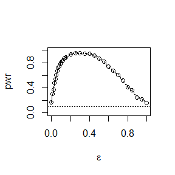

```r
##Examples 6.10
library(MASS)
set.seed(123)
alpha<-0.1
d<-2
n <-30 #sample sizes
cv <- qchisq(1-alpha,d*(d+1)*(d+2)/6) #crit. values for each n
sk <-function(x) {
  n<-nrow(x)
  for (j in 1:d) {
    x[,j]<-x[,j]-mean(x[,j])
  }
  s<-solve(cov(x))
  b<-1/n^2*sum(diag((x%*%s%*%t(x))^3))
  return(b*n/6)
}

m <- 2500 #replicates
epsilon <- c(seq(0, .15, .01), seq(.15, 1, .05))
N <- length(epsilon)
pwr <- numeric(N) #critical value for the skewness test

for (j in 1:N) {
  e <- epsilon[j]
  sktests <- numeric(m)
  for (i in 1:m) {
    sig <- sample(c(1,10), replace = TRUE, size = n, prob = c(1-e, e))
    x <- matrix(nr=n,nc=d)
    for (k in 1:n) {
      sigma<-diag(rep(sig[k],d))
       x[k,]<- mvrnorm(1,rep(0,d),sigma)
    }
    sktests[i] <- as.integer(sk(x) >= cv)
  }
  pwr[j] <- mean(sktests)
}
#plot power vs epsilon
plot(epsilon, pwr, type = "b", xlab = bquote(epsilon), ylim = c(0,1))
abline(h = .1, lty = 3)
se <- sqrt(pwr * (1-pwr) / m) #add standard errors
lines(epsilon, pwr+se, lty = 3)
lines(epsilon, pwr-se, lty = 3)
```

## 2021-10-28

## question

Exercises 7.7, 7.8, 7.9, and 7.B (pages 213, Statistical Computating with R)

$\mathbf{Answer1-7.7}$ The R code for this question is as follows:

```r
library(boot)
library(bootstrap)
set.seed(123)

lambda_hat=eigen(cov(scor))$values
theta_hat=lambda_hat[1]/sum(lambda_hat)
B=2000 ##number of replictes

theta_star=function(data,index){
  x=data[index,]
  lambda=eigen(cov(x))$values
  theta=lambda[1]/sum(lambda)
  return(theta)
}
bootstrap_result=boot(data=cbind(scor$mec, scor$vec, scor$alg, scor$ana, scor$sta),statistic = theta_star, R = B)
theta_b <- bootstrap_result$t
bias_boot <- mean(theta_b) - theta_hat# the estimated bias of theta_hat, using bootstrap
se_boot <- sqrt(var(theta_b))# the estimated standard error (se) of theta_hat, using bootstrap

# print the answers
list(bias_boot=bias_boot,se_boot=se_boot)
```

```
## $bias_boot
## [1] 0.00260599
##
## $se_boot
##            [,1]
## [1,] 0.04689501
```

$\mathbf{Answer1-7.8}$ The R code for this question is as follows:

```r
library(bootstrap)
set.seed(123)


lambda_hat=eigen(cov(scor))$values
theta_hat=lambda_hat[1]/sum(lambda_hat)
n=nrow(scor)

theta_j=numeric(n)
for(i in 1:n){
  x=scor[-i,]
  lambda=eigen(cov(x))$values
  theta_j[i]=lambda[1]/sum(lambda)
}
bias_jack=(n-1)*(mean(theta_j)-theta_hat)
se_jack=sqrt((n-1)*mean(((theta_j-mean(theta_j))^2)))

#print the answers
list(bias_jack=bias_jack,se_jack=se_jack)
```

```
## $bias_jack
## [1] 0.001069139
##
## $se_jack
## [1] 0.04955231
```

$\mathbf{Answer1-7.9}$ The R code for this question is as follows:

```r
library(boot)
library(bootstrap)
set.seed(123)

lambda_hat=eigen(cov(scor))$values
theta_hat=lambda_hat[1]/sum(lambda_hat)
B=2000 ##number of replictes

theta_star=function(data,index){
  x=data[index,]
  lambda=eigen(cov(x))$values
  theta=lambda[1]/sum(lambda)
  return(theta)
}
bootstrap_result=boot(data=cbind(scor$mec, scor$vec, scor$alg, scor$ana, scor$sta),statistic = theta_star, R = B)
boot.ci(bootstrap_result,conf = 0.95,type = c("perc","bca"))
```

```
## BOOTSTRAP CONFIDENCE INTERVAL CALCULATIONS
## Based on 2000 bootstrap replicates
##
## CALL :
## boot.ci(boot.out = bootstrap_result, conf = 0.95, type = c("perc",
##     "bca"))
##
## Intervals :
## Level     Percentile            BCa
## 95%   ( 0.5283,  0.7083 )   ( 0.5235,  0.7057 )
## Calculations and Intervals on Original Scale
```

$\mathbf{Answer1-7.B}$ The R code for this question is as follows:

```r
library(boot)
m=1e3#number of replicates

# normal populations
ci_norm.norm=ci_norm.basic=ci_norm.perc=matrix(NA,m,2)
boot_skew=function(x,i){
  mean((x-mean(x[i]))^3)/(mean((x-mean(x[i]))^2))^(1.5)
}
for(i in 1:m){
  x=rnorm(n)
  de=boot(data=x,statistic=boot_skew, R = 1000)
  ci_norm=boot.ci(de,conf=0.95,type=c("norm","basic","perc"))
  ci_norm.norm[i,]=ci_norm$norm[2:3];ci_norm.basic[i,]=ci_norm$basic[4:5];ci_norm.perc[i,]=ci_norm$percent[4:5]
}

# $chisq$(5) distribution
ci_chisq.norm=ci_chisq.basic=ci_chisq.perc=matrix(NA,m,2)
for(i in 1:m){
  y=rchisq(n,df=5)
  de=boot(data=y,statistic=boot_skew, R = 1000)
  ci_chisq=boot.ci(de,conf=0.95,type=c("norm","basic","perc"))
  ci_chisq.norm[i,]=ci_chisq$norm[2:3];ci_chisq.basic[i,]=ci_chisq$basic[4:5];ci_chisq.perc[i,]=ci_chisq$percent[4:5]
}
chisq.skew=sqrt(8/5)#the skewness of chisquare distribution

coverage_rate=c(mean(ci_norm.norm[,1]<=0 & ci_norm.norm[,2]>=0),
                mean(ci_norm.basic[,1]<=0 & ci_norm.basic[,2]>=0),
                mean(ci_norm.perc[,1]<=0 & ci_norm.perc[,2]>=0),
                mean(ci_chisq.norm[,1]<=chisq.skew & ci_chisq.norm[,2]>=chisq.skew),
                mean(ci_chisq.basic[,1]<=chisq.skew & ci_chisq.basic[,2]>=chisq.skew),
                mean(ci_chisq.perc[,1]<=chisq.skew & ci_chisq.perc[,2]>=chisq.skew))

proportipn_miss_on_the_left=c(mean(ci_norm.norm[,1]>0),
                              mean(ci_norm.basic[,1]>0),
                              mean(ci_norm.perc[,1]>0),
                              mean(ci_chisq.norm[,1]>chisq.skew),
                              mean(ci_chisq.basic[,1]>chisq.skew),
                              mean(ci_chisq.perc[,1]>chisq.skew))


proportipn_miss_on_the_right=c(mean(ci_norm.norm[,2]<0),
                               mean(ci_norm.basic[,2]<0),
                               mean(ci_norm.perc[,2]<0),
                               mean(ci_chisq.norm[,2]<chisq.skew),
                               mean(ci_chisq.basic[,2]<chisq.skew),
                               mean(ci_chisq.perc[,2]<chisq.skew))
cinames=c("ci_norm.norm","ci_norm.basic","ci_norm.perc","ci_chisq.norm","ci_chisq.basic","ci_chisq.perc")

df=data.frame(cinames=cinames,coverage_rate=coverage_rate,proportipn_miss_on_the_left=proportipn_miss_on_the_left,proportipn_miss_on_the_right=proportipn_miss_on_the_right)
library(knitr)

kable(df)
```

| cinames | coverage_rate | proportipn_miss_on_the_left | proportipn_miss_on_the_right |
| --- | --- | --- | --- |
| ci_norm.norm | 0.975 | 0.006 | 0.019 |
| ci_norm.basic | 0.967 | 0.007 | 0.026 |
| ci_norm.perc | 0.982 | 0.002 | 0.016 |
| ci_chisq.norm | 0.869 | 0.065 | 0.066 |
| ci_chisq.basic | 0.854 | 0.095 | 0.051 |
| ci_chisq.perc | 0.849 | 0.043 | 0.108 |

## 2021-11-04

## Question

一、Exercise 8.2 (page 242, Statistical Computating with R). 二、Design experiments for evaluating the performance of the NN,energy, and ball methods in various situations. 1. Unequal variances and equal expectations 2. Unequal variances and unequal expectations 3. Non-normal distributions: t distribution with 1 df (heavy-tailed distribution), bimodel distribution (mixture of two normal distributions) 4. Unbalanced samples (say, 1 case versus 10 controls) 5. Note: The parameters should be chosen such that the powers are distinguishable (say, range from 0.3 to 0.8)

## Answer

$\mathbf{Answer1-8.2}$ Solve: The R code for this question is as follows:

```r
attach(chickwts)
x <- sort(as.vector(weight[feed == "sunflower"]))
y <- sort(as.vector(weight[feed == "linseed"]))
detach(chickwts)
cat(x,'\n')
```

```
## 226 295 297 318 320 322 334 339 340 341 392 423
```

```r
cat(y,'\n')
```

```
## 141 148 169 181 203 213 229 244 257 260 271 309
```

```r
z <- c(x, y) # pooled sample
R <- 1500;K <- 1:24;n<-length(x)
set.seed(12345)
reps <- numeric(R);t0 <- cor(x, y,method ="spearman")
for (i in 1:R) {
k <- sample(K, size = n, replace = FALSE)
x1 <- z[k]; y1 <- z[-k] #complement of x1
reps[i] <- cor(x1, y1,method ="spearman")
}
p <- mean(abs(c(t0, reps)) >= abs(t0))
round(c(p,cor.test(x,y)$p.value),3)
```

```
## [1] 0.001 0.000
```

$\mathbf{conclusion：}$ Here the sample evidence supports the alternative hypothesis that the variables are highly correlated.

$\mathbf{Answer2}$ Solve: The R code for this question is as follows:

```r
library(RANN)
library(boot)
library(energy)
library(Ball)

Tn <- function(z, ix, sizes,k) {
n1 <- sizes[1]; n2 <- sizes[2]; n <- n1 + n2
if(is.vector(z)) z <- data.frame(z);
z <- z[ix, ];
NN <- nn2(data=z, k=k+1)
block1 <- NN$nn.idx[1:n1,-1]
block2 <- NN$nn.idx[(n1+1):n,-1]
i1 <- sum(block1 <= n1); i2 <- sum(block2 > n1)
(i1 + i2) / (k * n)
}

#Power comparison
m <- 1e3; k<-1; set.seed(12345)
n1 <- n2 <- 50; R<-999; n <- n1+n2; N <- c(n1,n2);
eqdist.nn <- function(z,sizes,k){
boot.obj <- boot(data=z,statistic=Tn,R=R,
sim = "permutation", sizes = sizes,k=k)
ts <- c(boot.obj$t0,boot.obj$t)
p.value <- mean(ts>=ts[1])
list(statistic=ts[1],p.value=p.value)
}
p1.values <- p2.values<-p3.values<-p4.values<-matrix(NA,m,3)

#Unequal variances and equal expectations
for(i in 1:m){
x1 <- rnorm(n1,0,1.5)
y1 <- rnorm(n2,0,1)
z1 <- c(x1,y1)
p1.values[i,1]<-eqdist.nn(z1,N,k)$p.value
p1.values[i,2]<-eqdist.etest(z1,sizes=N,R=R)$p.value
p1.values[i,3]<-bd.test(x=x1,y=y1,num.permutations=R,
seed=i*12345)$p.value
}
#Unequal variances and unequal expectations
for(i in 1:m){
x2 <- rnorm(n1,0,1.5)
y2 <- rnorm(n2,1,1)
z2 <- c(x2,y2)
p2.values[i,1]<-eqdist.nn(z2,N,k)$p.value
p2.values[i,2]<-eqdist.etest(z2,sizes=N,R=R)$p.value
p2.values[i,3]<-bd.test(x=x2,y=y2,num.permutations=R,
seed=i*12345)$p.value
}
#Non-normal distributions: t distribution with 1 df (heavy-tailed distribution),bimodel distribution (mixture of two normal distributions)
rMG <- function(n){
# randomly generate n points from the Mixed Gaussian distribution
r <- runif(n, 0, 1)
x <- r
ind <- which(r < 0.3) #index for those generated from N(0,1)
x[ind] <- rnorm(length(ind), 0, 1)
x[-ind] <- rnorm(n-length(ind), 1, 0.3)
return(x)
}
for(i in 1:m){
x3 <- rt(n1,df=1)
y3 <- rMG(n2)
z3 <- c(x3,y3)
p3.values[i,1]<-eqdist.nn(z3,N,k)$p.value
p3.values[i,2]<-eqdist.etest(z3,sizes=N,R=R)$p.value
p3.values[i,3]<-bd.test(x=x3,y=y3,num.permutations=R,
seed=i*12345)$p.value
}
#Unbalanced samples
for(i in 1:m){
x4 <- rnorm(5)
y4 <- rnorm(n2)
z4 <- c(x4,y4)
p4.values[i,1]<-eqdist.nn(z4,c(5,n2),k)$p.value
p4.values[i,2]<-eqdist.etest(z4,sizes=c(5,n2),R=R)$p.value
p4.values[i,3]<-bd.test(x=x4,y=y4,num.permutations=R,
seed=i*12345)$p.value
}

alpha <- 0.05;
pow1 <-colMeans(p1.values<alpha)
pow2 <-colMeans(p2.values<alpha)
pow3 <-colMeans(p3.values<alpha)
pow4 <-colMeans(p4.values<alpha)
test_names<-c("NN","energy"," ball")
df<-data.frame(test_names=test_names,uneqva_eqme=pow1,uneqva_uneqme=pow2,Non_normal_dist=pow3,Unbalanced_samples=pow4)
library(knitr)
kable(df)
```

| test_names | uneqva_eqme | uneqva_uneqme | Non_normal_dist | Unbalanced_samples |
| --- | --- | --- | --- | --- |
| NN | 0.123 | 0.352 | 0.855 | 0.044 |
| energy | 0.253 | 0.989 | 1.000 | 0.046 |
| ball | 0.479 | 0.977 | 1.000 | 0.048 |

$\mathbf{conclusion：}$ It is known by the output result that: 1.In the situation of Unequal variances and equal expectations,the energy,and ball methods perform better than NN. 2.In the situation of Unequal variances and unequal expectations,the energy,and ball methods perform better than NN,and the energy method perform best among the three. 3.In the situation of Non-normal distributions,the energy,and ball methods perform better than NN. 4.In the situation of Unbalanced samples,all of them perform not good.

## 2021-11-11

## Question

一、Exercies 9.3 and 9.8 (pages 277-278, Statistical Computating with R) 二、For each of the above exercise, use the Gelman-Rubin method to monitor convergence of the chain, and run the chain until it converges approximately to the target distribution according to $\hat{R}$ < 1.2.